# hormones

Rick Gilmore

9/26/2019

# Hormonal communication

- Chemicals secreted into blood
- Act on specific target tissues via receptors
- Produce specific effects

## Examples of substances that are both hormones and NTs

- Melatonin
- Epinephrine/adrenaline
- Oxytocin
- Vasopressin

## Behaviors under hormonal influence

### Ingestive (eating/ drinking)

- ￼Fluid levels
- Na, K, Ca levels
- Digestion
- Blood glucose levels

### Reproduction-related

- Sexual Maturation
- Mating
- Birth
- Care giving

### To threat/challenge

- Metabolism
- Heart rate, blood pressure
- Digestion
- Arousal

### Common factors

- Biological imperatives
- Proscribed in space and time
- Foraging/hunting
  - Find targets distributed in space, evaluate, act upon
- Often involve others

## Principles of hormonal action

- Gradual action
- Change intensity or probability of behavior
- Behavior influences/influenced by hormones
  - +/- Feedback
- Multiple effects on different tissues
- Produced in small amounts; released in bursts
- Levels vary daily, seasonally
  - or are triggered by specific external/internal events
- Effect cellular metabolism
- Influence only cells with receptors
- Point to point vs.“broadcast”
  - Wider broadcast than neuromodulators
- Fast vs. slow-acting
- Short-acting vs. long-acting
- Digital (yes-no) vs. analog (graded)
- Voluntary control vs. involuntary

### Similarities between neural and hormonal communication

- Chemical messengers stored for later release
- Release follows stimulation
- Action depends on specific receptors
- 2nd messenger systems common

### Hormonal release sites

[figure not shown]

```r
knitr::include_graphics("img/glands.jpg")
```

- CNS
  - Hypothalamus
  - *Pituitary*
    - *Anterior*
    - *Posterior*
  - Pineal gland
- Rest of body
  - *Thyroid*
  - *Adrenal (ad=adjacent, renal=kidney) gland*
    - *Adrenal cortex*
    - *Adrenal medulla*
  - *Gonads* (testes/ovaries)

## Two release systems from hypothalamus

### Direct release

- Hypothalamus (paraventricular, supraoptic nucleus) to
- Posterior pituitary
  - *Oxytocin*
  - *Arginine Vasopressin (AVP, vasopressin)*

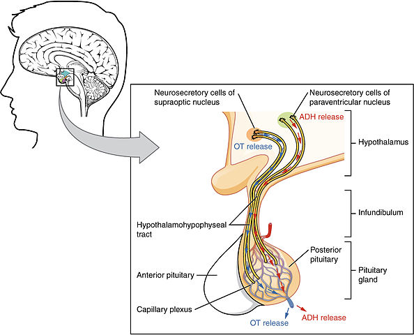

Source: https://upload.wikimedia.org/wikipedia/commons/thumb/7/70/1807_The_Posterior_Pituitary_Complex.jpg/594px-1807_The_Posterior_Pituitary_Complex.jpg

```r
knitr::include_graphics("https://upload.wikimedia.org/wikipedia/commons/thumb/7/70/1807_The_Posterior_Pituitary_Complex.jpg/594px-1807_The_Posterior_Pituitary_Complex.jpg")
```

### Indirect release

- Hypothalamus -> *releasing hormones*
- Anterior pituitary -> *tropic hormones*
- End organs

[figure not shown]

```r
knitr::include_graphics("img/indirect-release.jpg")
```

## Case studies

### Responses to threat or challenge

- Neural response
  - *Sympathetic Adrenal Medulla (SAM) response*
  - Sympathetic NS activation of adrenal medulla, other organs
  - Releases NE and Epi

[figure not shown]

[[@ulrich-lai_neural_2009]](http://doi.org/10.1038/nrn2647)

```r
knitr::include_graphics("http://www.nature.com/nrn/journal/v10/n6/images/nrn2647-i1.jpg")
```

- Endocrine response
  - *Hypothalamic Pituitary Adrenal (HPA) axis*
  - Adrenal hormones released
- Hypothalamus
  - *Corticotropin Releasing Hormone (CRH)*
- Anterior pituitary
  - *Adrenocorticotropic hormone (ACTH)*
- Adrenal cortex
  - *Glucocorticoids (e.g., cortisol)*
  - *Mineralocorticoids (e.g. aldosterone)*

[figure not shown]

[[@ulrich-lai_neural_2009]](http://doi.org/10.1038/nrn2647)

```r
knitr::include_graphics("http://www.nature.com/nrn/journal/v10/n6/images/nrn2647-i1.jpg")
```

### ￼Adrenal hormones

- *Steroids*
  - Derived from cholesterol
- *Cortisol*
  - increases blood glucose, anti-inflammatory effects
  - negative consequences of prolonged exposure
- *Aldosterone*
  - Regulates Na (and water)

## Reproductive behavior – the milk letdown reflex

- Supraoptic & Paraventricular nucleus (PVN) of hypothalamus releases oxytocin
  - Into bloodstream via posterior pituitary (endocrine)
  - Onto neurons in nucleus accumbens (neurocrine), amygdala, brainstem

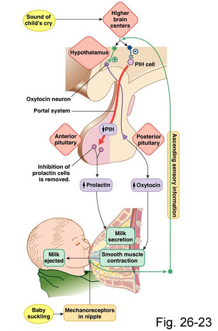

http://physiologyplus.com/wp-content/uploads/2017/05/milk-ejection-reflex.png

```r
knitr::include_graphics("http://physiologyplus.com/wp-content/uploads/2017/05/milk-ejection-reflex.png")
```

Oxytocin’s role…

- Sexual arousal
- Released in bursts during orgasm
- Stimulates uterine, vaginal contraction
- Links to social interaction, bonding [[@Weisman2013158]](http://dx.doi.org/10.1016/j.biopsych.2013.05.026)
- Alters face processing in autism [[@Domes2013164]](http://dx.doi.org/10.1016/j.biopsych.2013.02.007)
- May inhibit fear/anxiety-related behaviors by gating amygdala [[@viviani2011oxytocin]](http://doi.org/10.1126/science.1201043)

[figure not shown]

## Circadian rhythms

### Melatonin

- Diurnal rhythm
- Night time peak, early morning low
- Secretion suppressed by “blue” light (< 460-480 nm)
- Rhythm irregular until ~3 mos post-natal [[@Ardura2003-tw]](http://dx.doi.org/68571)
- Peak weakens, broadens with age

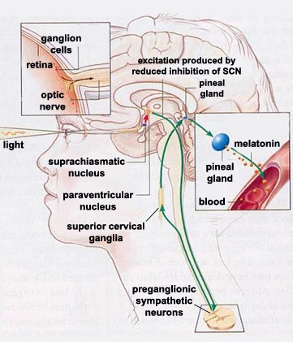

```r
knitr::include_graphics("http://thebrain.mcgill.ca/flash/a/a_11/a_11_cr/a_11_cr_hor/a_11_cr_hor_1a.jpg")
```

- Suprachiasmatic nucleus (SCN) of the hypothalamus
- Paraventricular nucleus of the hypothalamus
- Spinal cord
- Superior cervical ganglion
- Pineal gland

[video not shown]

## Thinking about neurochemical influences

- Measure hormones in blood, saliva; can’t effectively measure NTs
- Multivariate, nonlinear, mutually interacting
- Varied time scales
  - Phasic (e.g., cortisol in response to challenge)
  - Periodic (e.g., melatonin; diurnal cortisol)
- Peripheral effects + neural feedback
- State variables and behavior
  - Are your participants sleepy, hungry, horny, distressed…
  - Endogenous & exogenous influences

### Gut/brain connection

[figure not shown]

[[@Sarkar2016-qf]](https://doi.org/10.1016/j.tins.2016.09.002)

```r
knitr::include_graphics("https://ars.els-cdn.com/content/image/1-s2.0-S0166223616301138-gr1.jpg")
```